# Week 10 | Simple Logistical Regression

Brian Grant

6/22/2020

# Day 1

## Logistic Regression

Simple Logistic Regression

- notice that if your binomials have a value greater than 0, you can have the logistical regression have the y value set to [variable] > 0 so that it’ll accept anything above 0 as a success (i.e. ‘1’).

This week we’re collecting our own data for the Logistic Regression analysis.

Notice that for this we want the p-value to be GREATER than alpha. This is because the null hypothesis is backwards than normal: we’re TRYING to accept that null is true instead of trying to reject the null.

# Day 2

## Class Activity - Simple Logistic Regression (Part 2)

```r
library(mosaic)
KidsFeet.glm <- glm(sex == "B" ~ length,
                    data = KidsFeet,
                    family = binomial)
summary(KidsFeet.glm)
```

```
##
## Call:
## glm(formula = sex == "B" ~ length, family = binomial, data = KidsFeet)
##
## Deviance Residuals:
##     Min       1Q   Median       3Q      Max
## -1.6481  -1.0700   0.6443   1.1051   1.5607
##
## Coefficients:
##             Estimate Std. Error z value Pr(>|z|)
## (Intercept) -12.4860     6.9660  -1.792   0.0731 .
## length        0.5074     0.2818   1.801   0.0717 .
## ---
## Signif. codes:  0 '***' 0.001 '**' 0.01 '*' 0.05 '.' 0.1 ' ' 1
##
## (Dispersion parameter for binomial family taken to be 1)
##
##     Null deviance: 54.040  on 38  degrees of freedom
## Residual deviance: 50.339  on 37  degrees of freedom
## AIC: 54.339
##
## Number of Fisher Scoring iterations: 4
```

```r
coef1 <- KidsFeet.glm$coefficients
coef1
```

```
## (Intercept)      length
## -12.4859697   0.5073724
```

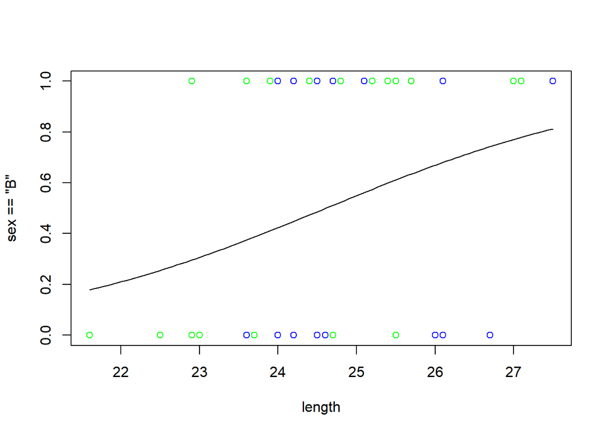

```r
plot(sex == "B" ~ length, data = KidsFeet, col = c("blue", "green"))
curve(exp(coef1[1] + coef1[2]*x)/(1 + exp(coef1[1]+coef1[2]*x)), add = TRUE)
```

```r
predict(KidsFeet.glm, newdata = data.frame(length = 0), type = "response")
```

```
##            1
## 3.779294e-06
```

```r
exp(coef1[2])
```

```
##   length
## 1.660921
```

# In class excercise

```r
#View(infert)
#?infert
infert.glm <- glm( (spontaneous > 0) ~ age, data=infert, family=binomial)

summary(infert.glm)
```

```
##
## Call:
## glm(formula = (spontaneous > 0) ~ age, family = binomial, data = infert)
##
## Deviance Residuals:
##     Min       1Q   Median       3Q      Max
## -1.3106  -1.0716  -0.8968   1.2381   1.6135
##
## Coefficients:
##             Estimate Std. Error z value Pr(>|z|)
## (Intercept)  1.48706    0.79786   1.864   0.0623 .
## age         -0.05616    0.02517  -2.231   0.0257 *
## ---
## Signif. codes:  0 '***' 0.001 '**' 0.01 '*' 0.05 '.' 0.1 ' ' 1
##
## (Dispersion parameter for binomial family taken to be 1)
##
##     Null deviance: 339.12  on 247  degrees of freedom
## Residual deviance: 334.01  on 246  degrees of freedom
## AIC: 338.01
##
## Number of Fisher Scoring iterations: 4
```

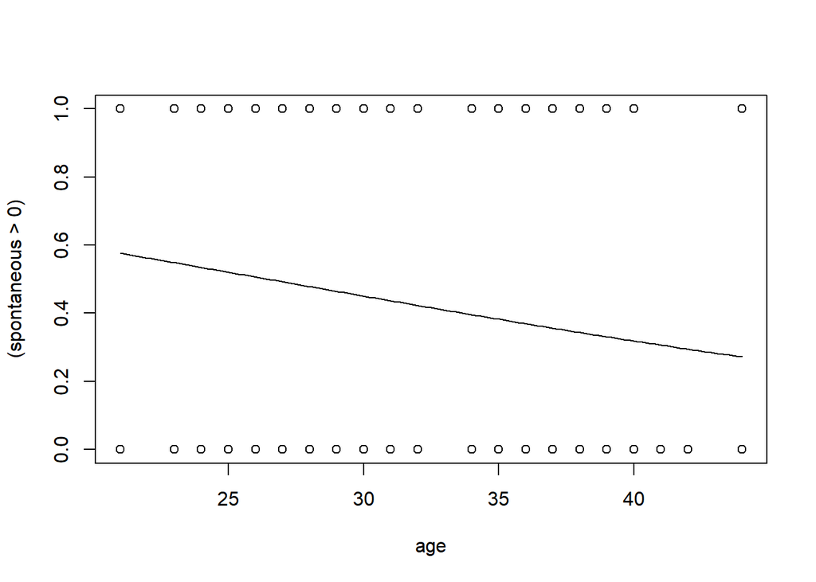

```r
plot( (spontaneous > 0) ~ age, data=infert)
curve( exp(1.48706 + -0.05616*x)/(1 + exp(1.48706 + -0.05616*x)), add=TRUE)
```

```r
table(infert$age)
```

```
##
## 21 23 24 25 26 27 28 29 30 31 32 34 35 36 37 38 39 40 41 42 44
##  6  6  3 15 15 15 30 12 12 21 15 18 18 15 12  8  9  6  3  6  3
```

```r
library(tidyverse)
```

```r
library(mosaic)
library(pander)
library(plyr)
#Residual deviance: 334.01  on 246  degrees of freedom
pchisq(334.01,
       246,
       lower.tail=FALSE)
```

```
## [1] 0.0001571274
```

```r
library(mosaic)
#View(Galton)
#?Galton

Galton.glm <- glm(sex == "M" ~ height,
                  data = Galton,
                  family = binomial)
summary(Galton.glm)
```

```
##
## Call:
## glm(formula = sex == "M" ~ height, family = binomial, data = Galton)
##
## Deviance Residuals:
##     Min       1Q   Median       3Q      Max
## -2.5425  -0.5068   0.0789   0.5046   3.2188
##
## Coefficients:
##              Estimate Std. Error z value Pr(>|z|)
## (Intercept) -52.98422    3.40240  -15.57   <2e-16 ***
## height        0.79683    0.05117   15.57   <2e-16 ***
## ---
## Signif. codes:  0 '***' 0.001 '**' 0.01 '*' 0.05 '.' 0.1 ' ' 1
##
## (Dispersion parameter for binomial family taken to be 1)
##
##     Null deviance: 1243.75  on 897  degrees of freedom
## Residual deviance:  626.22  on 896  degrees of freedom
## AIC: 630.22
##
## Number of Fisher Scoring iterations: 6
```

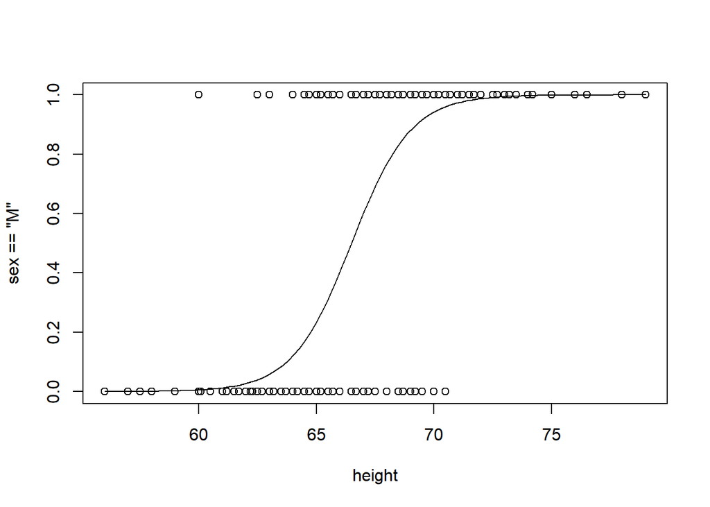

```r
coef.gal <- Galton.glm$coefficients

plot(sex == "M" ~ height,
     data = Galton)
curve(exp(coef.gal[1] + coef.gal[2]*x)/
        (1+exp(coef.gal[1]+coef.gal[2]*x)),
                                        add = TRUE)
```

# Assessment Quiz

## Q1

Run the following codes in R.

```r
  # library(mosaic)
  #
  # View(Gestation)
  #
  # ?Gestation
```

```r
Gest.glm <- glm(smoke > 0 ~ wt,
                data = Gestation,
                family = binomial)

summary(Gest.glm)
```

```
##
## Call:
## glm(formula = smoke > 0 ~ wt, family = binomial, data = Gestation)
##
## Deviance Residuals:
##     Min       1Q   Median       3Q      Max
## -1.8055  -1.2341   0.8984   1.0765   1.4810
##
## Coefficients:
##              Estimate Std. Error z value Pr(>|z|)
## (Intercept)  2.416983   0.402280   6.008 1.88e-09 ***
## wt          -0.018277   0.003311  -5.520 3.39e-08 ***
## ---
## Signif. codes:  0 '***' 0.001 '**' 0.01 '*' 0.05 '.' 0.1 ' ' 1
##
## (Dispersion parameter for binomial family taken to be 1)
##
##     Null deviance: 1684.0  on 1225  degrees of freedom
## Residual deviance: 1652.1  on 1224  degrees of freedom
##   (10 observations deleted due to missingness)
## AIC: 1656.1
##
## Number of Fisher Scoring iterations: 4
```

Answer: b0=2.417 and b1=−0.018

### Explanation

Call: glm(formula = smoke > 0 ~ wt, family = binomial, data = Gestation)

Deviance Residuals: Min 1Q Median 3Q Max  
-1.8055 -1.2341 0.8984 1.0765 1.4810

## Q2

Here is the output of a logistic regression performed in R.

Coefficients: Estimate Std. Error z value Pr(>|z|)  
(Intercept) -6.6035 2.3514 -2.808 0.00498 mpg 0.3070 0.1148 2.673 0.00751

What is the predicted value for P(Yi=1|xi=25) ?

```r
exp(-6.6035 + 0.3070*25) / (1 + exp(-6.6035 + 0.3070*25))
```

```
## [1] 0.7448821
```

Answer: 0.7448821

### Explanation

To compute a predicted value we can either do the calculation by hand:

exp(-6.6035 + 0.3070*25) / (1 + exp(-6.6035 + 0.3070*25)) = 0.7448821

Or we can use the predict function:

predict(glmObject, data.frame(mpg=25), type=“response”)

However, in this particular case, we don’t have access to the “glmObject” that created the summary output, so we can only compute the answer by hand.

## Q3

Consider again the logistic regression output shown below.

Coefficients: Estimate Std. Error z value Pr(>|z|)  
(Intercept) -6.6035 2.3514 -2.808 0.00498 mpg 0.3070 0.1148 2.673 0.00751

Which of the following correctly interprets these results

```r
exp(0.3070)
```

```
## [1] 1.359341
```

Answer: The odds that Yi=1 increase by 36% for every 1 unit change in x.

### Explanation

To intepret the effect of mpg (the x-variable) on the odds, we compute exp(0.3070), which gives the value of eb1 . See the Overview page of Logistic Regression for an explanation.

Coefficients: Estimate Std. Error z value Pr(>|z|)  
(Intercept) -6.6035 2.3514 -2.808 0.00498 mpg 0.3070 0.1148 2.673 0.00751

Since exp(0.3070) = 1.359341, we find that the odds of a success, i.e., that Yi =1 increases by 35.9341%, which rounds to 36% for every 1 unit increase in x.

Notices that the 35.9341 came from 1.359341. If you have 1.36 of what you originally had, then you increased by 0.36 or 36%.

100% - 136% = 36%